# Algorithms for Big Data - Exercise 3

This lecture is about introduction to CNNs.

We use validating sets, and evaluate our models on CIFAR-10 dataset.

We will also try the Batch normalization layer in Keras.

[Open in Google colab](https://colab.research.google.com/github/rasvob/2020-21-ARD/blob/master/abd_03.ipynb) [Download from Github](https://github.com/rasvob/2020-21-ARD/blob/master/abd_03.ipynb)

```python
from __future__ import absolute_import
from __future__ import division
from __future__ import print_function

import matplotlib.pyplot as plt # plotting
import matplotlib.image as mpimg # images
import numpy as np #numpy
import tensorflow.compat.v2 as tf #use tensorflow v2 as a main
import tensorflow.keras as keras # required for high level applications
from sklearn.model_selection import train_test_split # split for validation sets
from sklearn.preprocessing import normalize # normalization of the matrix
from scipy.signal import convolve2d # convolutionof the 2D signals
from tensorflow.keras.layers import Activation
from tensorflow.keras.utils import get_custom_objects
from tensorflow.keras.preprocessing.image import ImageDataGenerator

tf.version.VERSION
```

```
'2.8.0'
```

# Defining terms for CNN

## Convolution

A convolution is defined as the integral of the product of the two functions after one is reversed and shifted. It is a mathmematical way how to analyze behavior of the functions and the relation between the functions.

In image processing, **kernel** or **convolution matrix** or **mask** is a small matrix. In general the convolution in image processing is defined as:

$$g(x, y) = \omega * f(x,y) = \sum_{s=-a}^{a}\sum_{t=-b}^{b}\omega(s,t)f(x-s, y-t)$$

where $g(x,y)$ is filtered image, $f(x,y)$ is original image, $\omega$ if the filter kernel.

A kernel (also called a filter) is a smaller-sized matrix in comparison to the dimensions of the input image, that consists of real valued entries.

[figure not shown]

### Example filters

| Name | Definition |
| --- | --- |
| Identity | $\left[\begin{matrix}0&0&0\\0&1&0\\0&0&0\end{matrix}\right]$ |
| Sobel vertical edge detection | $\left[\begin{matrix}+1&0&-1\\+2&0&-2\\+1&0&-1\end{matrix}\right]$ |
| Sobel horizontal edge detection | $\left[\begin{matrix}+1&+2&+1\\0&0&0\\-1&-2&-1\end{matrix}\right]$ |
| Edge detection | $\left[\begin{matrix}-1&-1&-1\\-1&8&-1\\-1&-1&-1\end{matrix}\right]$ |
| Sharpen | $\left[\begin{matrix}0&-1&0\\-1&5&-1\\0&-1&0\end{matrix}\right]$ |
| Uniform blur | $\frac{1}{9}\left[\begin{matrix}1&1&1\\1&1&1\\1&1&1\end{matrix}\right]$ |
| Gaussian blur 3x3 | $\frac{1}{16}\left[\begin{matrix}1&2&1\\2&4&2\\1&2&1\end{matrix}\right]$ |

## Padding

One tricky issue when applying convolutional is losing pixels on the edges of our image. A straightforward solution to this problem is to add extra pixels around the boundary of our input image, which increases the effective size of the image.

[figure not shown]

### Practical example of convolution and padding without TF

```python
def rgb2gray(rgb):
    return np.dot(rgb[...,:3], [0.2989, 0.5870, 0.1140])

lena_img_url = 'https://raw.githubusercontent.com/jplatos/2019-2020-DA4/master/images/lena.png'
img = rgb2gray(mpimg.imread(lena_img_url))
img = img/255.0
img.shape
```

```
(512, 512)
```

[figure not shown]

```python
plt.imshow(img, cmap='gray')
```

[figure not shown]

```python
blur_mask = np.ones((3,3))/9.0
edge_mask = np.ones((3,3))*-1
edge_mask[1, 1] = 8
mask = np.array([
    [ 0,-1, 0],
    [-1, 4,-1],
    [ 0,-1, 0]
    ])

img_blur = convolve2d(img, blur_mask, boundary='symm', mode='same')
result = np.clip(convolve2d(img_blur, mask, boundary='symm', mode='same'), 0, 1)
plt.imshow(result, cmap='gray')
```

## Pooling

Pooling is a way how to decrease the amount of information transfered from one layer to another. The standard way ho to do it is Average Pooling and Maximum Pooling.

- Pooling results in (some) invariance to translation because shifting the image slightly does not change the activation map significantly. This property is referred to as translation invariance.
- The idea is that similar images often have very different relative locations of the distinctive shapes within them, and translation invariance helps in being able to classify such images in a similar way.
  - For example, one should be able to classify a bird as a bird, irrespective of where it occurs in the image.
  - Disadvantege is that you can for example succesfully classify image as face even though the position of eyes and mouth is switched, because model doesn't care about location of features in the image, their presence is for the model enough
- Avg. pooling is rarely used, usually we use max-pooling in the hidden layers, the only exception might be the last layer, where avg. pooling can significantly reduce the number of parameters.
- One alternative to using fully connected layers is to use average pooling across the whole spatial area of the final set of activation maps to create a single value.
  - Therefore, the number of features created in the final spatial layer will be exactly equal to the number of filters. In this scenario, if the final activation maps are of size 7 × 7 × 256, then 256 features will be created.
  - Each feature will be the result of aggregating 49 values. This type of approach greatly reduces the parameter footprint of the fully connected layers

[figure not shown]

# Note about shapes

- Convolution - increases depth - e.g. If you start with grayscale image with depth = 1 and apply Conv2D with 32 filters, output will have depth = 32
- Pooling - reduces width and height, but depth stays the same

## Tensorflow implementation of the Convolution Neural Network

### Some utility functions

Here is some functions we will use later several times

- **show_history** - show history of the **fit** method

```python
def show_history(history):
    plt.figure()
    for key in history.history.keys():
        plt.plot(history.epoch, history.history[key], label=key)
    plt.legend()
    plt.tight_layout()

def show_example(train_x, train_y, class_names=None):
    plt.figure(figsize=(10,10))
    for i in range(25):
        plt.subplot(5,5,i+1)
        plt.xticks([])
        plt.yticks([])
        plt.grid(False)
        plt.imshow(train_x[i], cmap=plt.cm.binary)
        if class_names is not None:
          plt.xlabel(class_names[train_y[i][0]])
    plt.show()

def display_activation(activations, col_size, row_size, act_index):
    activation = activations[act_index]
    activation_index=0
    fig, ax = plt.subplots(row_size, col_size, figsize=(row_size*2.5,col_size*1.5))
    for row in range(0,row_size):
        for col in range(0,col_size):
            ax[row][col].imshow(activation[0, :, :, activation_index], cmap='gray')
            if activation_index < activation.shape[3]-1:
                activation_index += 1
```

#### Dataset load

- downloaded
- splitted into train and test set
- converted from the range <0,255> into <0, 1>
- *train* is splitted into *train* and *validation* set
- class names are defined

```python
# cifar is the basic dataset for image classifaction
dataset = tf.keras.datasets.cifar10

# data from any dataset are loaded using the load_Data function
(train_x, train_y), (test_x, test_y) = dataset.load_data()

# kind of normalization..
train_x = train_x/255.0
test_x = test_x/255.0

train_x, valid_x, train_y, valid_y = train_test_split(train_x, train_y, test_size=0.2, random_state=42)

# the data are in the form of 32x32 pixes with values 0-255.
print('Train data shape: ', train_x.shape, train_y.shape)
print('Validation data shape: ', valid_x.shape, valid_y.shape)
print('Test data shape:  ', test_x.shape, test_y.shape)

class_names = ['airplane', 'automobile', 'bird', 'cat', 'deer', 'dog', 'frog', 'horse', 'ship', 'truck']
class_count = len(class_names)
print('Class count:', class_count, class_names)
```

```
Train data shape:  (40000, 32, 32, 3) (40000, 1)
Validation data shape:  (10000, 32, 32, 3) (10000, 1)
Test data shape:   (10000, 32, 32, 3) (10000, 1)
Class count: 10 ['airplane', 'automobile', 'bird', 'cat', 'deer', 'dog', 'frog', 'horse', 'ship', 'truck']
```

#### Show example images of the dataset

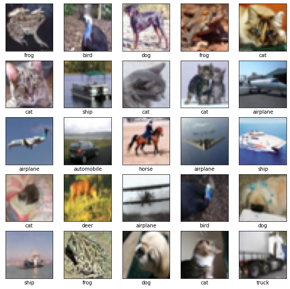

```python
show_example(train_x, train_y, class_names)
```

#### Definition of the model

The base model is defined as *Sequential* with 2 convolutional layers.

Summarization of the model and compilation is done similarly as well.

### We can use any activation function we want, very common choice is ReLU or Leaky ReLU

#### Another very popular activation function nowadays is Mish (it's not only one, there are more Swish etc.)

Mish

```python
class Mish(Activation):
    '''
    Mish Activation Function.
    .. math::
        mish(x) = x * tanh(softplus(x)) = x * tanh(ln(1 + e^{x}))
    Shape:
        - Input: Arbitrary. Use the keyword argument `input_shape`
        (tuple of integers, does not include the samples axis)
        when using this layer as the first layer in a model.
        - Output: Same shape as the input.
    Examples:
        >>> X = Activation('Mish', name="conv1_act")(X_input)
    '''

    def __init__(self, activation, **kwargs):
        super(Mish, self).__init__(activation, **kwargs)
        self.__name__ = 'Mish'


def mish(inputs):
    return inputs * tf.math.tanh(tf.math.softplus(inputs))

get_custom_objects().update({'mish': Mish(mish)})
```

```python
model = keras.Sequential([
    keras.layers.Conv2D(32, (3,3), activation='relu', input_shape=(32, 32, 3)),
    keras.layers.MaxPooling2D((2, 2)),
    keras.layers.Conv2D(16, (3,3), activation='relu'),
    keras.layers.Flatten(),
    keras.layers.Dense(64, activation='relu'),
    keras.layers.Dense(class_count)
])

model.summary()

model.compile(loss=keras.losses.SparseCategoricalCrossentropy(from_logits=True),
              optimizer='adam',
              metrics=['accuracy'])
```

```
Model: "sequential"
_________________________________________________________________
 Layer (type)                Output Shape              Param #
=================================================================
 conv2d (Conv2D)             (None, 30, 30, 32)        896

 max_pooling2d (MaxPooling2D  (None, 15, 15, 32)       0
 )

 conv2d_1 (Conv2D)           (None, 13, 13, 16)        4624

 flatten (Flatten)           (None, 2704)              0

 dense (Dense)               (None, 64)                173120

 dense_1 (Dense)             (None, 10)                650

=================================================================
Total params: 179,290
Trainable params: 179,290
Non-trainable params: 0
_________________________________________________________________
```

#### Fit the model for defined number of epochs.

Show the history of learning, evaluate the efficiency of the model.

```
Test accuracy:  0.647599995136261
```

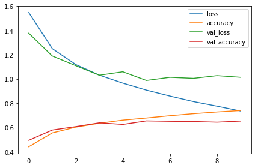

```python
history = model.fit(train_x, train_y, batch_size=32, validation_data=(valid_x, valid_y), epochs=10)

show_history(history)

test_loss, test_acc = model.evaluate(test_x, test_y)
print('Test accuracy: ', test_acc)
```

#### Vizualization of the confusion matrix.

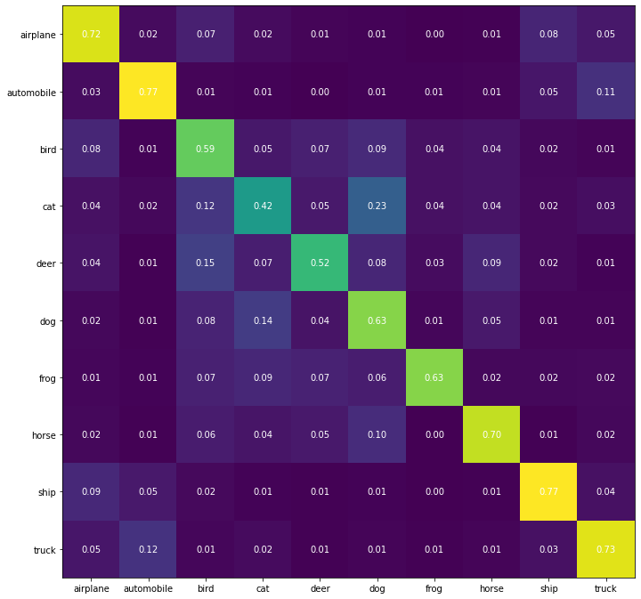

```python
predictions = model.predict(test_x)
conf_matrix = np.zeros((class_count, class_count))
for idx, pred in enumerate(predictions):
    row = test_y[idx]
    col = np.argmax(pred)
    conf_matrix[row, col] += 1

# print(conf_matrix)
conf_matrix = normalize(conf_matrix, axis=1, norm='l1')
# print(conf_matrix)

plt.figure(figsize=(class_count,class_count))

plt.imshow(conf_matrix)

for i in range(conf_matrix.shape[0]):
    for j in range(conf_matrix.shape[1]):
        text = plt.text(j, i, "{:.2f}".format(conf_matrix[i, j]), ha="center", va="center", color="w")

plt.xticks(range(class_count), class_names)
plt.yticks(range(class_count), class_names)

plt.tight_layout()
plt.show()
```

### Save and Load of the model

The model I/O works as follows. The topology of the model is usually stored separately from the weights. The reason is that the topology is usually used once, but the weights are used frequently and they develop during the learning process.

The topology is stored as JSON file format, as is demonstrated later in more human readable form. As you may see, the document is very simple and just summarize the layers and its types - app parameters set during the model creation.

The weights are stored using the HDF5 file format a format developed for fast unlimited storage with portable and distributable capabilities.

```python
file_model = 'model.json'
file_weight = 'model.h5'

# serialize model to JSON
model_json = model.to_json()
with open(file_model, "w") as json_file:
    json_file.write(model_json)
# serialize weights to HDF5
model.save_weights(file_weight)
print("Saved model to disk")
```

```
Saved model to disk
```

[output not shown]

### Loading model

The model is also loadable separatelly. Topology and weights.

```python
# load json and create model
json_file = open('model.json', 'r')
loaded_model_json = json_file.read()
json_file.close()
loaded_model = keras.models.model_from_json(loaded_model_json)
# load weights into new model
loaded_model.load_weights("model.h5")
print("Loaded model from disk")
```

```
Loaded model from disk
```

The model need to be compiled to be applicable to the data.As you may see the summary of the model is the same as was for the previous one.

```python
loaded_model.compile(loss=keras.losses.SparseCategoricalCrossentropy(from_logits=False),
              optimizer='adam',
              metrics=['accuracy'])

loaded_model.summary()
```

```
Model: "sequential"
_________________________________________________________________
 Layer (type)                Output Shape              Param #
=================================================================
 conv2d (Conv2D)             (None, 30, 30, 32)        896

 max_pooling2d (MaxPooling2D  (None, 15, 15, 32)       0
 )

 conv2d_1 (Conv2D)           (None, 13, 13, 16)        4624

 flatten (Flatten)           (None, 2704)              0

 dense (Dense)               (None, 64)                173120

 dense_1 (Dense)             (None, 10)                650

=================================================================
Total params: 179,290
Trainable params: 179,290
Non-trainable params: 0
_________________________________________________________________
```

```python
test_loss, test_acc = loaded_model.evaluate(test_x, test_y)
print('Test accuracy: ', test_acc)
```

```
Test accuracy:  0.647599995136261
```

## Visualize the layers

Lest see what the network was able to learn from the train data. For that, we need to prepare a new model and see the ouputs of the layers.

```python
# get the outputs form all layers in the model
layer_outputs = [layer.output for layer in model.layers]
# create the model that has single input and as an output all the outputs from the layers.
# Because the layers are connected then the output from first layer is propagated into second layer and the output is computed o it.
activation_model = keras.models.Model(inputs=model.input, outputs=layer_outputs)
```

```python
# get all the outputs from the model for 10-th input
activations = activation_model.predict(train_x[10].reshape((1, 32, 32, 3)))
```

```python
layer_outputs
```

```
[<KerasTensor: shape=(None, 30, 30, 32) dtype=float32 (created by layer 'conv2d')>,
 <KerasTensor: shape=(None, 15, 15, 32) dtype=float32 (created by layer 'max_pooling2d')>,
 <KerasTensor: shape=(None, 13, 13, 16) dtype=float32 (created by layer 'conv2d_1')>,
 <KerasTensor: shape=(None, 2704) dtype=float32 (created by layer 'flatten')>,
 <KerasTensor: shape=(None, 64) dtype=float32 (created by layer 'dense')>,
 <KerasTensor: shape=(None, 10) dtype=float32 (created by layer 'dense_1')>]
```

## Visualize the layers

Lest see what the network was able to learn from the train data. For that, we need to prepare a new model and see the ouputs of the layers.

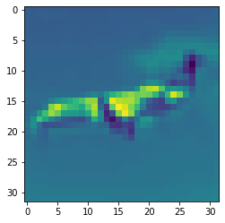

```python
# show the input image
plt.imshow(train_x[10][:,:,0]);
```

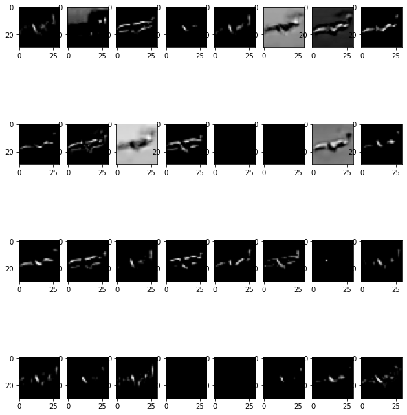

```python
# show the output from the first layer - CNN2D
display_activation(activations, 8, 4, 0)
```

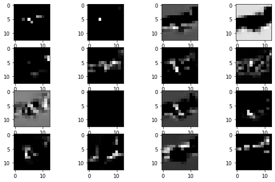

```python
# show the second convolution layer
display_activation(activations, 4, 4, 2)
```

# Batch normalization

- If we have some two input variables with scales from 0 to 1 and from 0 to 1000 we can normalize them
  - Larger scale does not mean that the varible is more important than the other one
  - It's clear that without normalization one weight will be very high and other very low to balance the scale difference
  - This leads to slow gradient descent convergence - we need small learning rates
    - Loss function space is not smooth - gradients may oscillate back and forth before finding optimum
- This issue is present in hidden layers as well due to the mini-batch learning
  - Each batch is different from others from distributions point of view
  - Covariate shift effect - distribution of data is constantly changing during training
    - E.g. We train model on images of black cats - we learn how to map input X to output Y
    - If we now use images of colored cats for testing purposes the model will fail - input X changed thus learned mapping is invalid
    - This shift happens internally with mini-batches all the time
- Batch norm. standardize activation values to have same mean and variance among batch
  - Slight regularization - it adds some noise to each hidden layer’s activations so less overfitting
  - We can use higher learning rates because batch normalization makes sure that there’s no activation that’s gone really high or really low
  - It makes the landscape of the corresponding optimization problem be significantly more smooth. This ensures, in particular, that the gradients are more predictive and thus allow for use of larger range of learning rates and faster network convergence
- Keras: tf.keras.layers.BatchNormalization
  - Usually after Conv or Dense layers
  - There are of course multiple different approaches where the batch norm. can be placed

## How to use Data augmentation?

- There might be bug present in the TF2 currently, so beware the label encoding
- We need to one-hot encode the labels and change the loss function to the CategoricalCrossentropy, note that the output activation function is now set to softmax
- Take a look at [this](https://www.tensorflow.org/api_docs/python/tf/keras/preprocessing/image/ImageDataGenerator)

```python
# cifar is the basic dataset for image classifaction
dataset = tf.keras.datasets.cifar10

# data from any dataset are loaded using the load_Data function
(train_x, train_y), (test_x, test_y) = dataset.load_data()

class_names = ['airplane', 'automobile', 'bird', 'cat', 'deer', 'dog', 'frog', 'horse', 'ship', 'truck']
class_count = len(class_names)

train_y = tf.keras.utils.to_categorical(train_y, class_count)
test_y = tf.keras.utils.to_categorical(test_y, class_count)

train_x = train_x/255.0
test_x = test_x/255.0

train_x, valid_x, train_y, valid_y = train_test_split(train_x, train_y, test_size=0.2, random_state=42)

# the data are in the form of 32x32 pixes with values 0-255.
print('Train data shape: ', train_x.shape, train_y.shape)
print('Validation data shape: ', valid_x.shape, valid_y.shape)
print('Test data shape:  ', test_x.shape, test_y.shape)
print('Class count:', class_count, class_names)
```

```
Train data shape:  (40000, 32, 32, 3) (40000, 10)
Validation data shape:  (10000, 32, 32, 3) (10000, 10)
Test data shape:   (10000, 32, 32, 3) (10000, 10)
Class count: 10 ['airplane', 'automobile', 'bird', 'cat', 'deer', 'dog', 'frog', 'horse', 'ship', 'truck']
```

```python
datagen = ImageDataGenerator(
#     featurewise_center=True,
#     featurewise_std_normalization=True,
#     rotation_range=20,
#     width_shift_range=0.2,
#     height_shift_range=0.2,
    horizontal_flip=True,
    validation_split=0.2)
datagen.fit(train_x)

epochs = 20

model = keras.Sequential([
    keras.layers.Conv2D(128, (5,5), activation='mish', input_shape=(32, 32, 3)),
    keras.layers.MaxPooling2D(),
    keras.layers.Conv2D(64, (3,3), activation='mish', padding='same'),
    keras.layers.Dropout(0.2),
    keras.layers.Conv2D(64, (3,3), activation='mish'),
    keras.layers.Dropout(0.2),
    keras.layers.Flatten(),
    keras.layers.Dense(64, activation='relu'),
    keras.layers.Dense(class_count, activation='softmax')
])

model.summary()
```

```
Model: "sequential_1"
_________________________________________________________________
 Layer (type)                Output Shape              Param #
=================================================================
 conv2d_2 (Conv2D)           (None, 28, 28, 128)       9728

 max_pooling2d_1 (MaxPooling  (None, 14, 14, 128)      0
 2D)

 conv2d_3 (Conv2D)           (None, 14, 14, 64)        73792

 dropout (Dropout)           (None, 14, 14, 64)        0

 conv2d_4 (Conv2D)           (None, 12, 12, 64)        36928

 dropout_1 (Dropout)         (None, 12, 12, 64)        0

 flatten_1 (Flatten)         (None, 9216)              0

 dense_2 (Dense)             (None, 64)                589888

 dense_3 (Dense)             (None, 10)                650

=================================================================
Total params: 710,986
Trainable params: 710,986
Non-trainable params: 0
_________________________________________________________________
```

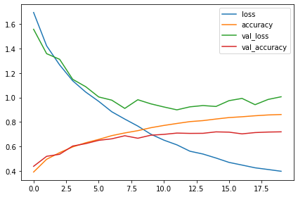

```python
model.compile(
              loss=keras.losses.CategoricalCrossentropy(),
              optimizer='adam',
              metrics=['accuracy'])

history = model.fit(datagen.flow(train_x, train_y,batch_size=32,
         subset='training'),  validation_data=datagen.flow(train_x, train_y,
         batch_size=32, subset='validation'), epochs=epochs)
show_history(history)
```

```python
test_loss, test_acc = model.evaluate(test_x, test_y)
print('Test accuracy: ', test_acc)
```

```
Test accuracy:  0.7196999788284302
```

## Tasks for Lecture

[output not shown]

1. Design a model which will be able to classify **CIFAR10** with accuracy higher than **80%**.
2. Try to work with MNIST and FashionMnist datasets asan image - 99% on **Mnist** is achievable using CNN, 94% on **Fashion-Mnist** too.

# Design a model which will be able to classify CIFAR10 with accuracy higher than 80%.

```
Train data shape:  (40000, 32, 32, 3) (40000, 1)
Validation data shape:  (10000, 32, 32, 3) (10000, 1)
Test data shape:   (10000, 32, 32, 3) (10000, 1)
Class count: 10 ['airplane', 'automobile', 'bird', 'cat', 'deer', 'dog', 'frog', 'horse', 'ship', 'truck']
Model: "sequential_17"
_________________________________________________________________
 Layer (type)                Output Shape              Param #
=================================================================
 conv2d_101 (Conv2D)         (None, 32, 32, 32)        896

 batch_normalization (BatchN  (None, 32, 32, 32)       128
 ormalization)

 conv2d_102 (Conv2D)         (None, 32, 32, 32)        9248

 batch_normalization_1 (Batc  (None, 32, 32, 32)       128
 hNormalization)

 max_pooling2d_47 (MaxPoolin  (None, 16, 16, 32)       0
 g2D)

 dropout_16 (Dropout)        (None, 16, 16, 32)        0

 conv2d_103 (Conv2D)         (None, 16, 16, 64)        18496

 batch_normalization_2 (Batc  (None, 16, 16, 64)       256
 hNormalization)

 conv2d_104 (Conv2D)         (None, 16, 16, 64)        36928

 batch_normalization_3 (Batc  (None, 16, 16, 64)       256
 hNormalization)

 max_pooling2d_48 (MaxPoolin  (None, 8, 8, 64)         0
 g2D)

 dropout_17 (Dropout)        (None, 8, 8, 64)          0

 conv2d_105 (Conv2D)         (None, 8, 8, 128)         73856

```

[output cut: 12 more lines]

```

 flatten_17 (Flatten)        (None, 2048)              0

 dense_48 (Dense)            (None, 128)               262272

 dropout_19 (Dropout)        (None, 128)               0

 dense_49 (Dense)            (None, 10)                1290

=================================================================
Total params: 552,362
Trainable params: 551,466
Non-trainable params: 896
_________________________________________________________________
Test accuracy:  0.8355000019073486
```

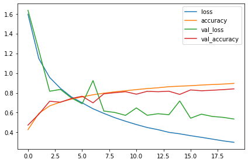

```python
# cifar is the basic dataset for image classifaction
dataset = tf.keras.datasets.cifar10

# data from any dataset are loaded using the load_Data function
(train_x, train_y), (test_x, test_y) = dataset.load_data()

# kind of normalization..
train_x = train_x/255.0
test_x = test_x/255.0

train_x, valid_x, train_y, valid_y = train_test_split(train_x, train_y, test_size=0.2, random_state=42)

# the data are in the form of 32x32 pixes with values 0-255.
print('Train data shape: ', train_x.shape, train_y.shape)
print('Validation data shape: ', valid_x.shape, valid_y.shape)
print('Test data shape:  ', test_x.shape, test_y.shape)

class_names = ['airplane', 'automobile', 'bird', 'cat', 'deer', 'dog', 'frog', 'horse', 'ship', 'truck']
class_count = len(class_names)
print('Class count:', class_count, class_names)




model = keras.Sequential([
      tf.keras.layers.Conv2D(filters=32, kernel_size=(3, 3), input_shape=(32, 32, 3), activation='relu', padding='same'),
      tf.keras.layers.BatchNormalization(),
      tf.keras.layers.Conv2D(filters=32, kernel_size=(3, 3), input_shape=(32, 32, 3), activation='relu', padding='same'),
      tf.keras.layers.BatchNormalization(),
      tf.keras.layers.MaxPool2D(pool_size=(2, 2)),
      tf.keras.layers.Dropout(0.25),
      tf.keras.layers.Conv2D(filters=64, kernel_size=(3, 3), input_shape=(32, 32, 3), activation='relu', padding='same'),
      tf.keras.layers.BatchNormalization(),
      tf.keras.layers.Conv2D(filters=64, kernel_size=(3, 3), input_shape=(32, 32, 3), activation='relu', padding='same'),
      tf.keras.layers.BatchNormalization(),
      tf.keras.layers.MaxPool2D(pool_size=(2, 2)),
      tf.keras.layers.Dropout(0.25),
      tf.keras.layers.Conv2D(filters=128, kernel_size=(3, 3), input_shape=(32, 32, 3), activation='relu', padding='same'),
      tf.keras.layers.BatchNormalization(),
      tf.keras.layers.Conv2D(filters=128, kernel_size=(3, 3), input_shape=(32, 32, 3), activation='relu', padding='same'),
      tf.keras.layers.BatchNormalization(),
      tf.keras.layers.MaxPool2D(pool_size=(2, 2)),
      tf.keras.layers.Dropout(0.25),
      tf.keras.layers.Flatten(),
      tf.keras.layers.Dense(128, activation='relu'),
      tf.keras.layers.Dropout(0.25),
      tf.keras.layers.Dense(10, activation='softmax'),
])

model.summary()

model.compile(loss=keras.losses.SparseCategoricalCrossentropy(from_logits=False),
              optimizer='adam',
              metrics=['accuracy']
              )

callback = keras.callbacks.EarlyStopping(monitor='val_accuracy', patience=5, restore_best_weights=True)


history = model.fit(train_x, train_y, batch_size=64, validation_data=(valid_x, valid_y), shuffle=True, epochs=20, callbacks=[callback])

show_history(history)

test_loss, test_acc = model.evaluate(test_x, test_y)
print('Test accuracy: ', test_acc)
```

```python
predictions = model.predict(test_x)
conf_matrix = np.zeros((class_count, class_count))
for idx, pred in enumerate(predictions):
    row = test_y[idx]
    col = np.argmax(pred)
    conf_matrix[row, col] += 1

# print(conf_matrix)
conf_matrix = normalize(conf_matrix, axis=1, norm='l1')
# print(conf_matrix)

plt.figure(figsize=(class_count,class_count))

plt.imshow(conf_matrix)

for i in range(conf_matrix.shape[0]):
    for j in range(conf_matrix.shape[1]):
        text = plt.text(j, i, "{:.2f}".format(conf_matrix[i, j]), ha="center", va="center", color="w")

plt.xticks(range(class_count), class_names)
plt.yticks(range(class_count), class_names)

plt.tight_layout()
plt.show()
```

[output not shown]

# Try to work with MNIST and FashionMnist datasets asan image - 99% on **Mnist** is achievable using CNN, 94% on **Fashion-Mnist** too.m

## MNIST - 99

```python
# cifar is the basic dataset for image classifaction
dataset = tf.keras.datasets.mnist

# data from any dataset are loaded using the load_Data function
(train_x, train_y), (test_x, test_y) = dataset.load_data()

# kind of normalization..
train_x = train_x/255.0
test_x = test_x/255.0

train_x, valid_x, train_y, valid_y = train_test_split(train_x, train_y, test_size=0.2, random_state=42)

# the data are in the form of 32x32 pixes with values 0-255.
print('Train data shape: ', train_x.shape, train_y.shape)
print('Validation data shape: ', valid_x.shape, valid_y.shape)
print('Test data shape:  ', test_x.shape, test_y.shape)
```

```
Train data shape:  (48000, 28, 28) (48000,)
Validation data shape:  (12000, 28, 28) (12000,)
Test data shape:   (10000, 28, 28) (10000,)
```

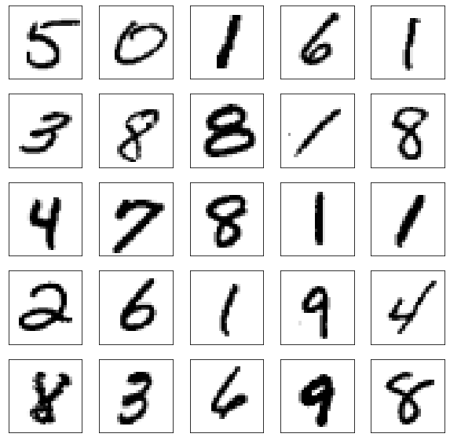

```python
show_example(train_x, train_y)
```

```
Model: "sequential_14"
_________________________________________________________________
 Layer (type)                Output Shape              Param #
=================================================================
 conv2d_83 (Conv2D)          (None, 28, 28, 32)        320

 conv2d_84 (Conv2D)          (None, 28, 28, 32)        9248

 max_pooling2d_38 (MaxPoolin  (None, 14, 14, 32)       0
 g2D)

 conv2d_85 (Conv2D)          (None, 14, 14, 64)        18496

 conv2d_86 (Conv2D)          (None, 14, 14, 64)        36928

 max_pooling2d_39 (MaxPoolin  (None, 7, 7, 64)         0
 g2D)

 conv2d_87 (Conv2D)          (None, 7, 7, 128)         73856

 conv2d_88 (Conv2D)          (None, 7, 7, 128)         147584

 max_pooling2d_40 (MaxPoolin  (None, 3, 3, 128)        0
 g2D)

 flatten_14 (Flatten)        (None, 1152)              0

 dense_39 (Dense)            (None, 64)                73792

 dropout_13 (Dropout)        (None, 64)                0

 dense_40 (Dense)            (None, 128)               8320

 dense_41 (Dense)            (None, 10)                1290

=================================================================
Total params: 369,834
Trainable params: 369,834
Non-trainable params: 0
_________________________________________________________________
Test accuracy:  0.9927999973297119
```

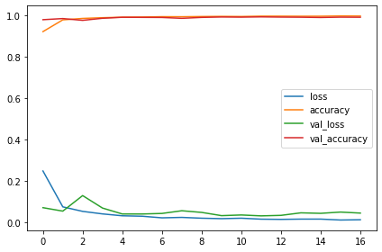

```python
model = keras.Sequential([
    keras.layers.Conv2D(32, (3, 3), activation='relu', kernel_initializer='he_uniform', padding='same', input_shape=(28, 28, 1)),
    keras.layers.Conv2D(32, (3, 3), activation='relu', kernel_initializer='he_uniform', padding='same'),
    keras.layers.MaxPooling2D((2, 2)),
    keras.layers.Conv2D(64, (3, 3), activation='relu', kernel_initializer='he_uniform', padding='same'),
    keras.layers.Conv2D(64, (3, 3), activation='relu', kernel_initializer='he_uniform', padding='same'),
    keras.layers.MaxPooling2D((2, 2)),
    keras.layers.Conv2D(128, (3, 3), activation='relu', kernel_initializer='he_uniform', padding='same'),
    keras.layers.Conv2D(128, (3, 3), activation='relu', kernel_initializer='he_uniform', padding='same'),
    keras.layers.MaxPooling2D((2, 2)),
    keras.layers.Flatten(),
    keras.layers.Dense(64, activation='relu', kernel_initializer='he_uniform'),
    keras.layers.Dropout(0.2),
    keras.layers.Dense(128, activation='relu', kernel_initializer='he_uniform'),
    keras.layers.Dense(10, activation=tf.nn.softmax)
])

model.summary()

model.compile(loss=keras.losses.SparseCategoricalCrossentropy(from_logits=False),
              optimizer='adam',
              metrics=['accuracy']
              )

callback = keras.callbacks.EarlyStopping(monitor='val_accuracy', patience=5, restore_best_weights=True)


history = model.fit(train_x, train_y, batch_size=32, validation_data=(valid_x, valid_y), shuffle=True, epochs=20, callbacks=[callback])

show_history(history)

test_loss, test_acc = model.evaluate(test_x, test_y)
print('Test accuracy: ', test_acc)
```

```python
# cifar is the basic dataset for image classifaction
dataset = tf.keras.datasets.fashion_mnist

# data from any dataset are loaded using the load_Data function
(train_x, train_y), (test_x, test_y) = dataset.load_data()

# kind of normalization..
train_x = train_x/255.0
test_x = test_x/255.0

train_x, valid_x, train_y, valid_y = train_test_split(train_x, train_y, test_size=0.2, random_state=42)

# the data are in the form of 32x32 pixes with values 0-255.
print('Train data shape: ', train_x.shape, train_y.shape)
print('Validation data shape: ', valid_x.shape, valid_y.shape)
print('Test data shape:  ', test_x.shape, test_y.shape)
```

```
Train data shape:  (48000, 28, 28) (48000,)
Validation data shape:  (12000, 28, 28) (12000,)
Test data shape:   (10000, 28, 28) (10000,)
```

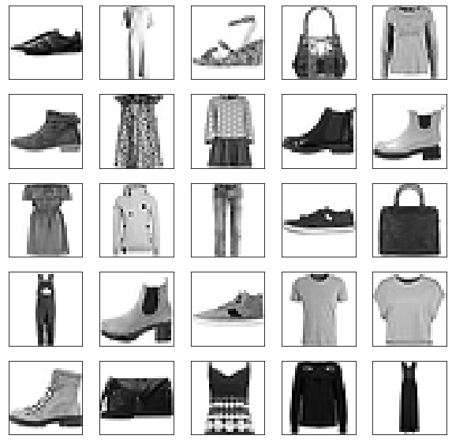

```python
show_example(train_x, train_y)
```

```
Model: "sequential_16"
_________________________________________________________________
 Layer (type)                Output Shape              Param #
=================================================================
 conv2d_95 (Conv2D)          (None, 28, 28, 32)        320

 conv2d_96 (Conv2D)          (None, 28, 28, 32)        9248

 max_pooling2d_44 (MaxPoolin  (None, 14, 14, 32)       0
 g2D)

 conv2d_97 (Conv2D)          (None, 14, 14, 64)        18496

 conv2d_98 (Conv2D)          (None, 14, 14, 64)        36928

 max_pooling2d_45 (MaxPoolin  (None, 7, 7, 64)         0
 g2D)

 conv2d_99 (Conv2D)          (None, 7, 7, 128)         73856

 conv2d_100 (Conv2D)         (None, 7, 7, 128)         147584

 max_pooling2d_46 (MaxPoolin  (None, 3, 3, 128)        0
 g2D)

 flatten_16 (Flatten)        (None, 1152)              0

 dense_45 (Dense)            (None, 64)                73792

 dropout_15 (Dropout)        (None, 64)                0

 dense_46 (Dense)            (None, 128)               8320

 dense_47 (Dense)            (None, 10)                1290

=================================================================
Total params: 369,834
Trainable params: 369,834
Non-trainable params: 0
_________________________________________________________________
Test accuracy:  0.9208999872207642
```

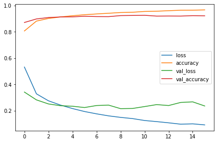

```python
model = keras.Sequential([
    keras.layers.Conv2D(32, (3, 3), activation='relu', kernel_initializer='he_uniform', padding='same', input_shape=(28, 28, 1)),
    keras.layers.Conv2D(32, (3, 3), activation='relu', kernel_initializer='he_uniform', padding='same'),
    keras.layers.MaxPooling2D((2, 2)),
    keras.layers.Conv2D(64, (3, 3), activation='relu', kernel_initializer='he_uniform', padding='same'),
    keras.layers.Conv2D(64, (3, 3), activation='relu', kernel_initializer='he_uniform', padding='same'),
    keras.layers.MaxPooling2D((2, 2)),
    keras.layers.Conv2D(128, (3, 3), activation='relu', kernel_initializer='he_uniform', padding='same'),
    keras.layers.Conv2D(128, (3, 3), activation='relu', kernel_initializer='he_uniform', padding='same'),
    keras.layers.MaxPooling2D((2, 2)),
    keras.layers.Flatten(),
    keras.layers.Dense(64, activation='relu', kernel_initializer='he_uniform'),
    keras.layers.Dropout(0.2),
    keras.layers.Dense(128, activation='relu', kernel_initializer='he_uniform'),
    keras.layers.Dense(10, activation='softmax')
])

model.summary()

model.compile(loss=keras.losses.SparseCategoricalCrossentropy(from_logits=False),
              optimizer='adam',
              metrics=['accuracy']
              )

callback = keras.callbacks.EarlyStopping(monitor='val_accuracy', patience=5, restore_best_weights=True)


history = model.fit(train_x, train_y, batch_size=32, validation_data=(valid_x, valid_y), shuffle=True, epochs=20, callbacks=[callback])

show_history(history)

test_loss, test_acc = model.evaluate(test_x, test_y)
print('Test accuracy: ', test_acc)
```